# Refining your plots, reports and code

MSc in Statistics 2025/26, Imperial College London

Author

Zak Varty

# Welcome Back!

## Today’s objectives

1. use R code within Quarto for single-document literate programming tasks
2. critique and refine default R outputs (such as plots and tables) for reports
3. understand how and when to show code within reports
4. use style guides and directory templates to provide a consistent structure across projects

# Literate Programming

## What is literate programming?

- A paradigm that combines:
  - **Code** (that executes)
  - **Narrative** (that explains)
- Result: documents that are both **human-readable** and **machine-executable**

Examples of literate programming software: Rmarkdown, JuPyteR, Quarto.

## What is Quarto?

[Quarto](https://quarto.org/) is a tool that lets us compile `.md`, `.ipynb`, `.Rmd` or `.qmd` files into pdf of html documents (reports, websites, books, slides).

Quarto succeeds RMarkdown with back-compatibility. This means you can use it from the command line or integrate with your favourite text editor.

## Adding code blocks

The basic markdown we have met already forms the backbone writing quarto documents. What makes it literate programming is the inclusion of code.

You have seen many examples in the first two workshops fo code blocks.

````markdown
```{r}
# use :: to access data or functions from within a package
penguins <- palmerpenguins::penguins
```
````

```r
# use :: to access data or functions from within a package
penguins <- palmerpenguins::penguins
```

## Unwanted Warnings

Sometimes you get warnings that you don’t need to draw attention to in your final document.

```r
library(palmerpenguins)
```

## Suppressing Warnings

````markdown
```{r}
#| warning: false
library(palmerpenguins)
```
````

```r
library(palmerpenguins)
```

## Code blocks that show but don’t run

Sometimes you want people to do as you say, not as you do. For example, I might want to ask you to install a package but without downloading it every time these notes are rendered.

````markdown
```{r}
#| eval: false
install.packages("palmerpengins")
```
````

```r
install.packages("palmerpengins")
```

## Code blocks that run but don’t show

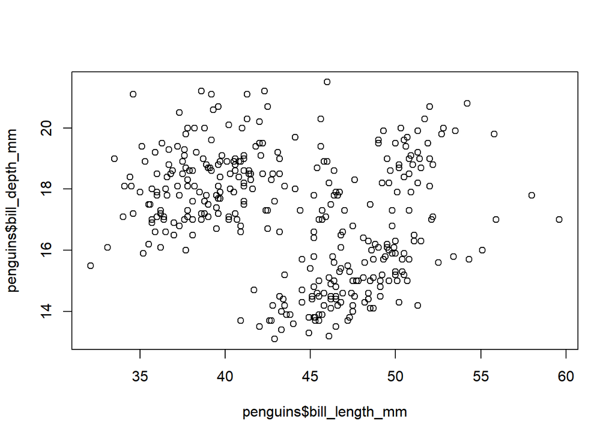

````markdown
```{r}
#| echo: false
plot(x = penguins$bill_length_mm,
     y = penguins$bill_depth_mm)
```
````

## Multiple outputs

When you have multiple objects being printed in a single block, these will often get split up when the document is rendered.

````markdown
```{r}
mean(penguins$body_mass_g, na.rm = TRUE)
median(penguins$body_mass_g, na.rm = TRUE)
```
````

```r
mean(penguins$body_mass_g, na.rm = TRUE)
```

```
[1] 4201.754
```

```r
median(penguins$body_mass_g, na.rm = TRUE)
```

```
[1] 4050
```

## Multiple outputs (`hold`)

Top keep this displaying as a single block, you can set `results` to `hold`.

````markdown
```{r}
#| results: hold
mean(penguins$body_mass_g, na.rm = TRUE)
median(penguins$body_mass_g, na.rm = TRUE)
```
````

```r
mean(penguins$body_mass_g, na.rm = TRUE)
median(penguins$body_mass_g, na.rm = TRUE)
```

```
[1] 4201.754
[1] 4050
```

## Motivating Example

To give us an example to play with, we could consider the following question: are the average weights of all species of penguin the same?

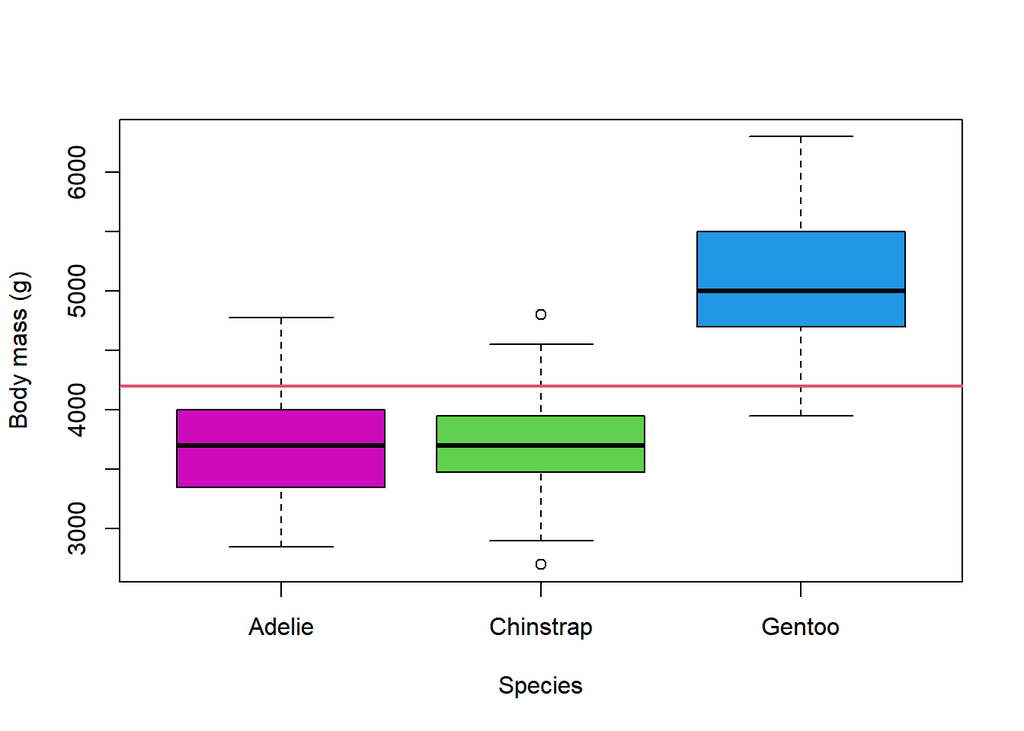

## Tables

How many penguins of each species do we have?

```r
table(penguins$species)
```

```
   Adelie Chinstrap    Gentoo
      152        68       124
```

```r
# fit linear model
mass_lm <- lm(formula = body_mass_g ~ 1 + species, penguins)

# extract coefficients and standard errors
mass_lm_coefficients <- summary(mass_lm)$coefficients[,1:2]
mass_lm_coefficients
```

```
                   Estimate Std. Error
(Intercept)      3700.66225   37.61935
speciesChinstrap   32.42598   67.51168
speciesGentoo    1375.35401   56.14797
```

## Nicer Tables

### Example 1

```r
species_counts <- table(penguins$species)
knitr::kable(species_counts, col.names = c("Species", "Count"))
```

| Species | Count |
| --- | --- |
| Adelie | 152 |
| Chinstrap | 68 |
| Gentoo | 124 |

### Example 2

```r
knitr::kable(x = mass_lm_coefficients)
```

|  | Estimate | Std. Error |
| --- | --- | --- |
| (Intercept) | 3700.66225 | 37.61935 |
| speciesChinstrap | 32.42598 | 67.51168 |
| speciesGentoo | 1375.35401 | 56.14797 |

We could set the row names to improve formatting.

```r
row.names(mass_lm_coefficients) <- c("Intercept", "Chinstrap", "Gentoo")
knitr::kable(x = mass_lm_coefficients)
```

|  | Estimate | Std. Error |
| --- | --- | --- |
| Intercept | 3700.66225 | 37.61935 |
| Chinstrap | 32.42598 | 67.51168 |
| Gentoo | 1375.35401 | 56.14797 |

And then refine the column names.

```r
knitr::kable(
  x = mass_lm_coefficients,
  col.names = c("MLE", "Std. Err"))
```

|  | MLE | Std. Err |
| --- | --- | --- |
| Intercept | 3700.66225 | 37.61935 |
| Chinstrap | 32.42598 | 67.51168 |
| Gentoo | 1375.35401 | 56.14797 |

Finally, we really don’t need to be showing all of those decimal places.

```r
knitr::kable(
  x = round(mass_lm_coefficients, 2),
  col.names = c("MLE", "Std. Err"))
```

|  | MLE | Std. Err |
| --- | --- | --- |
| Intercept | 3700.66 | 37.62 |
| Chinstrap | 32.43 | 67.51 |
| Gentoo | 1375.35 | 56.15 |

## A Semi-scripted approach

In report-style assessments you will not usually display your code in the main body of the report. In that case you can still use literate programming but you should:

- hide all of your code blocks
- clearly section your code with structural comments
- include an extra code block at the end of the report (this is in the template by default).

```r
#######################
# Question 3
#######################

# Part A --------------------------

# simulate data
n <- 100
x <- rnorm(n, mean = 0, sd = 1)
y <- rnorm(n, mean = x, sd = abs(x) / 2)
type <- ifelse(x > 0, "A", "B")

# collect and clean workspace
sim <- data.frame(x, y, type)
rm(n, x, y, type)
```

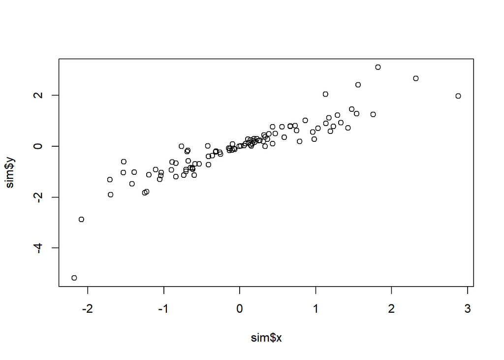

```r
# Part B --------------------------
plot(x = sim$x, y = sim$y)
```

# Labeling and Referencing

## Referencing TLDR

Quarto allows us to add hyperlinked references to many parts of the docuements we write.

This is useful because these references will auto-update if we modify or reorder the content of our document.

To reference a part of the document, you first label it and then reference that label.

- Label items of markdown using the `{#type-label}`
- Label code output with the `#| label: type-label`
- Reference either in the main text using `@type-label`

Standard reference types: `sec`, `fig`, `tbl`, `eq`.

Examples to follow and for full documentation see [Quarto Cross-References](https://quarto.org/docs/authoring/cross-references.html).

**NOTE:** The coursework template demonstrates an alternative referencing method using the {bookdown} package.

## Referencing Sections and Subsections

```markdown
# Labeling and Referencing {#sec-labeling}
...
@sec-labeling focuses on labelling and referencing parts of your document.
```

Section 3 focuses on labelling and referencing parts of your document.

## Referencing Tables

````markdown
```{r}
#| label: tbl-palmer
#| tbl-cap: "Example rows of the Palmer penguin dataset."

library(knitr)
kable(head(penguins))
```
````

```r
library(knitr)
kable(head(penguins)[ ,1:6])
```

Table 1: Example rows of the Palmer penguin dataset.

| species | island | bill_length_mm | bill_depth_mm | flipper_length_mm | body_mass_g |
| --- | --- | --- | --- | --- | --- |
| Adelie | Torgersen | 39.1 | 18.7 | 181 | 3750 |
| Adelie | Torgersen | 39.5 | 17.4 | 186 | 3800 |
| Adelie | Torgersen | 40.3 | 18.0 | 195 | 3250 |
| Adelie | Torgersen | NA | NA | NA | NA |
| Adelie | Torgersen | 36.7 | 19.3 | 193 | 3450 |
| Adelie | Torgersen | 39.3 | 20.6 | 190 | 3650 |

Table 1 gives example data entries from the Palmer penguins dataset. In your reports, all tables should have a caption and be discussed in the main text.

## Referencing Figures

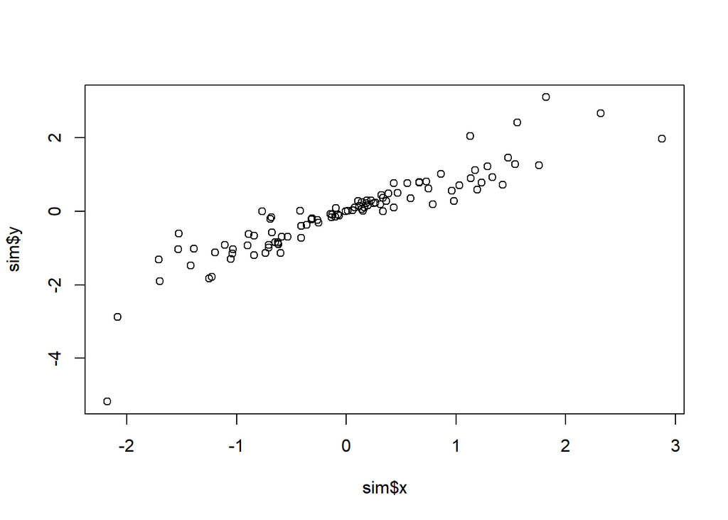

Figure 1

```r
plot(x = sim$x, y = sim$y)
```

Simulating data can be an important tool to understand how models behave in ideal conditions. Figure 1 shows an example of some bivariate data, simulated in Section 2.13.

## Referencing Equations

```markdown
$$ e^{\pi i} + 1 = 0.$${#eq-euler}
```

$$e^{\pi i} + 1 = 0. \tag{1}$$

Equation 1 states an elegant and well known result. By convention, equations should only be numbered if they are mentioned in the main text.

## Citing Sources

Add a bibliography to your document using the bibliography YAML metadata field. As for LaTeX this should point to a `.bib` file, detailing the sources you will cite. I have provided a small example bibliography file `ref.bib`.

```markdown
---
title: "Refining your plots, reports and code"
bibliography: ref.bib
---
```

By default, Pandoc will automatically generate a list of works cited and place it in the document if the style calls for it. It will be placed in a div with the id refs if one exists:

```markdown
### References

::: {#refs}
:::
```

To cite books or articles you can use a direct citation to talk about a source such as Box and Cox (1964) within a sentence, or a parenthetical reference to evidence a more general claim (Casella and Berger 2024) .

Markdown Syntax:

- `@box1964analysis` gives Box and Cox (1964);
- `[@casella2024statistical]` gives (Casella and Berger 2024).

Further information in the [citation documentation](https://quarto.org/docs/authoring/citations.html).

# Refining Your Figures

## A basic plot

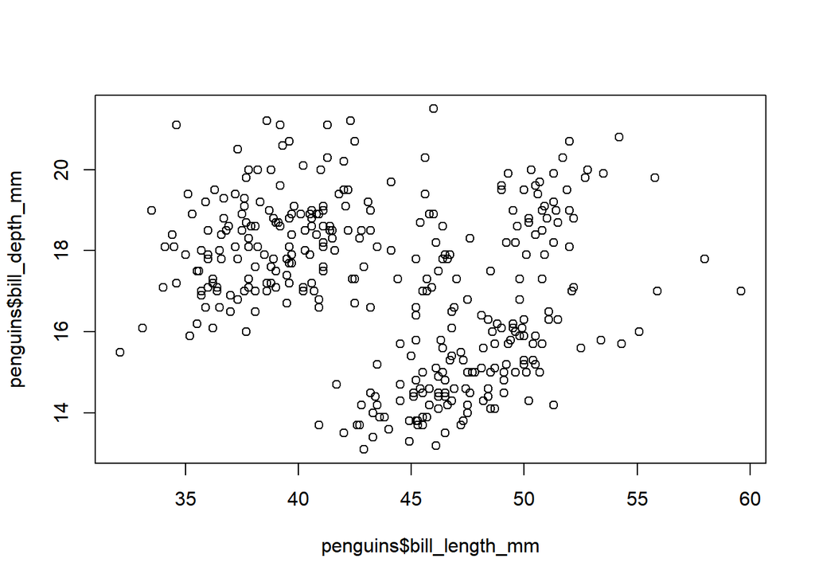

```r
plot(x = penguins$bill_length_mm, y = penguins$bill_depth_mm)
```

## Titles and Subtitles

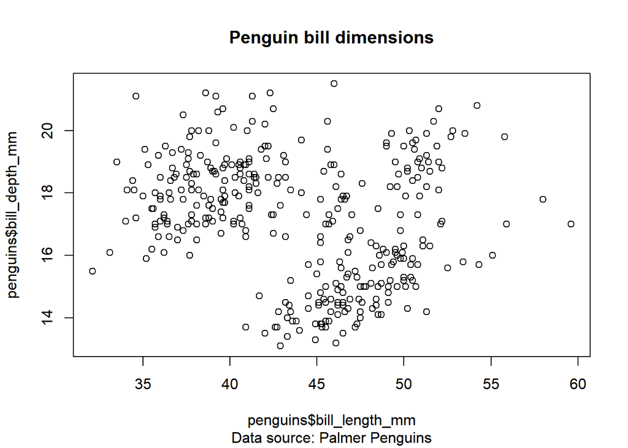

```r
plot(
  x = penguins$bill_length_mm,
  y = penguins$bill_depth_mm,
  main = "Penguin bill dimensions",
  sub = "Data source: Palmer Penguins")
```

## Axis Labels

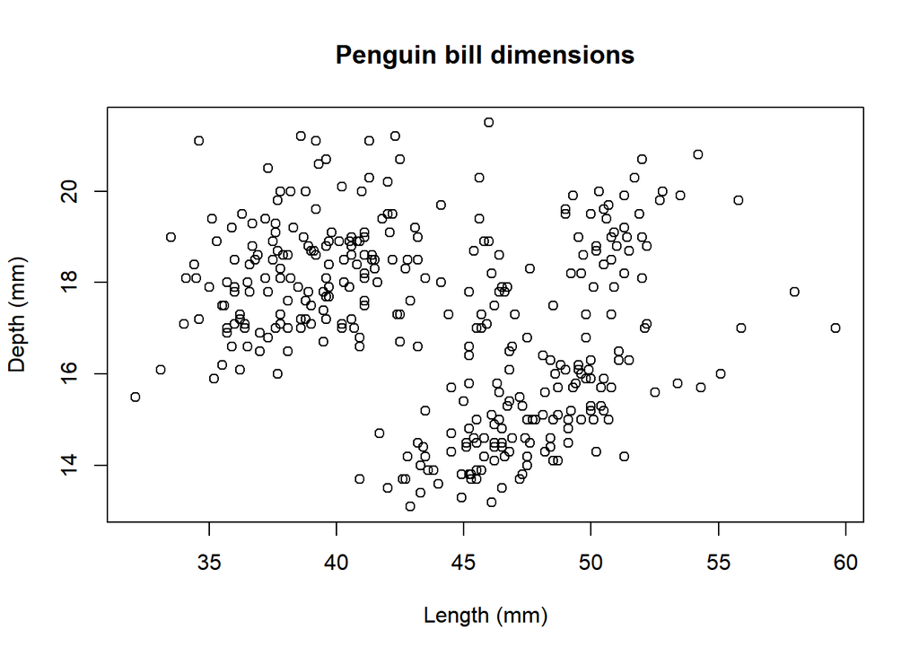

```r
plot(
  x = penguins$bill_length_mm,
  y = penguins$bill_depth_mm,
  main = "Penguin bill dimensions",
  xlab = "Length (mm)",
  ylab = "Depth (mm)")
```

## Resizing Axis Labels

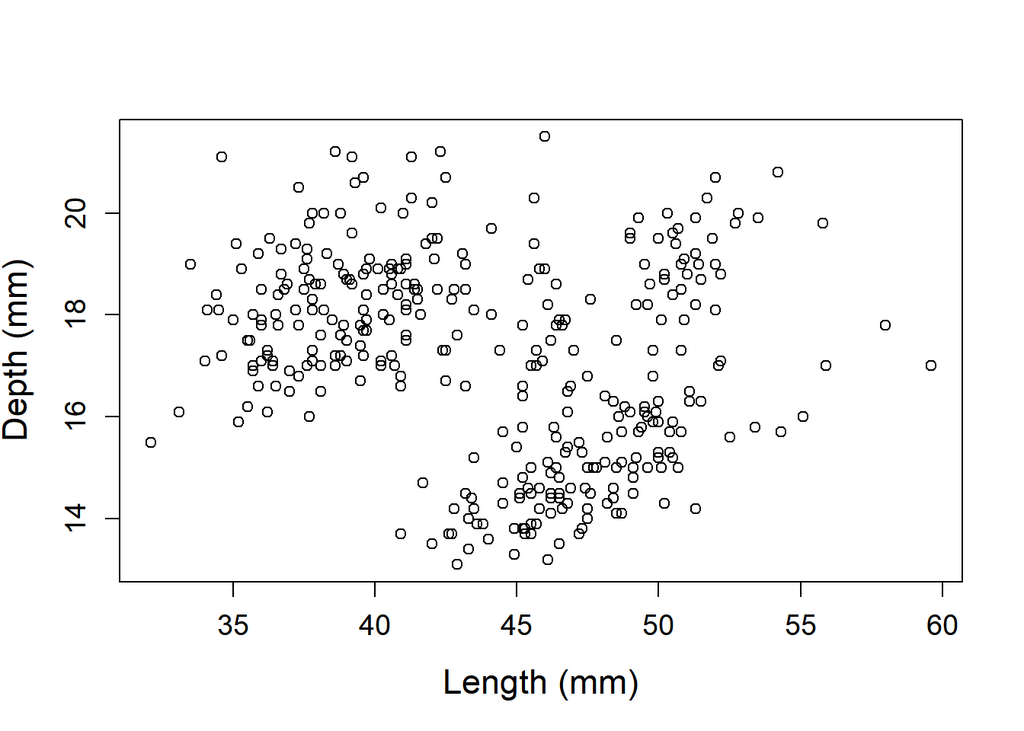

```r
plot(
  x = penguins$bill_length_mm,
  y = penguins$bill_depth_mm,
  xlab = "Length (mm)",
  ylab = "Depth (mm)",
  cex.axis = 1.2, # relative scaling of axis values
  cex.lab = 1.4)  # relative scaling of axis labels
```

## Visual Grammar

### Plotting Characters

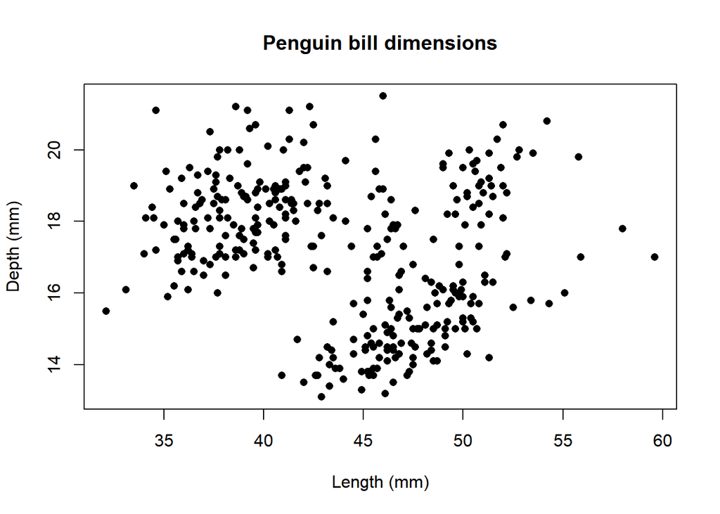

```r
plot(
  x = penguins$bill_length_mm,
  y = penguins$bill_depth_mm,
  main = "Penguin bill dimensions",
  xlab = "Length (mm)",
  ylab = "Depth (mm)",
  pch = 16)
```

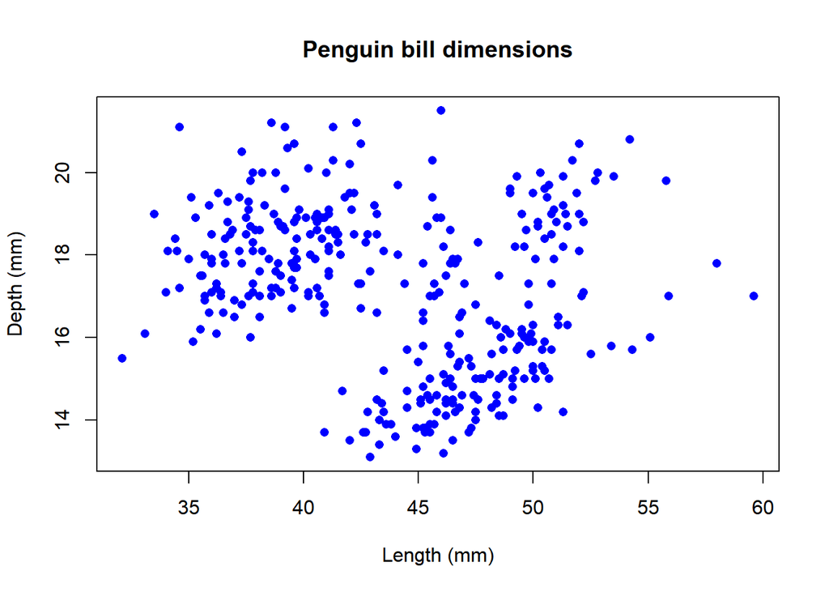

```r
plot(
  x = penguins$bill_length_mm,
  y = penguins$bill_depth_mm,
  main = "Penguin bill dimensions",
  xlab = "Length (mm)",
  ylab = "Depth (mm)",
  pch = 16,
  col = "blue")
```

Over-plotting happens when one point or line in a figure obscures another. We can resolve this issue by picking a transparent colour using `rgb()`.

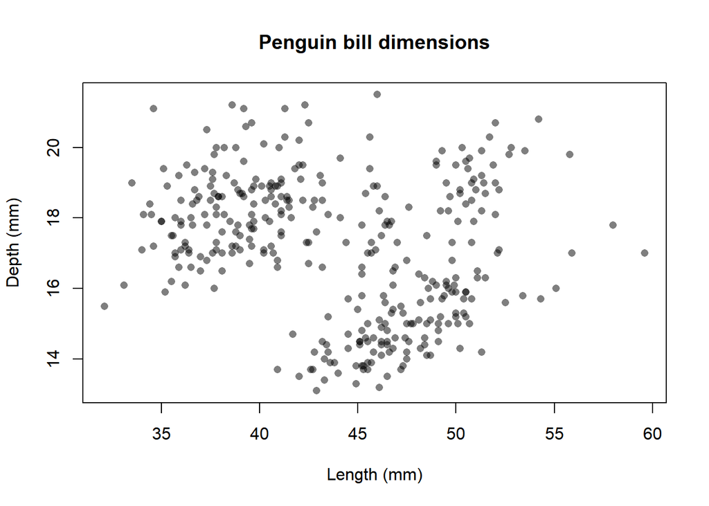

```r
plot(
  x = penguins$bill_length_mm,
  y = penguins$bill_depth_mm,
  main = "Penguin bill dimensions",
  xlab = "Length (mm)",
  ylab = "Depth (mm)",
  pch = 16,
  col = rgb(0,0,0,0.5))
```

We could also use colour to encode another aspect of our data visually.

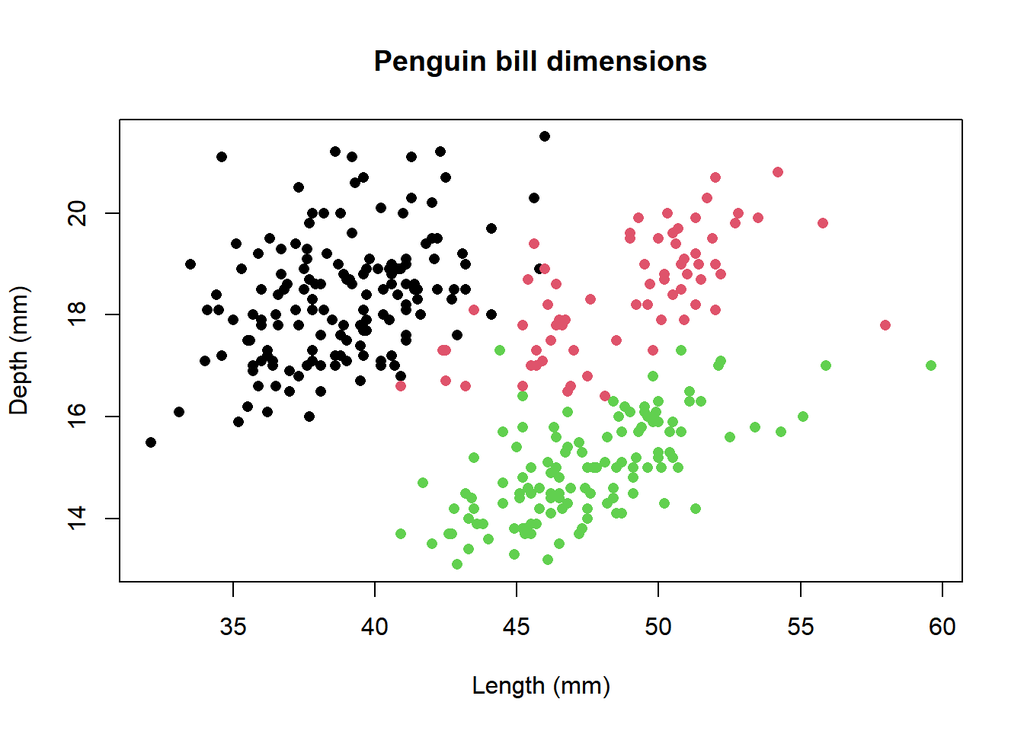

Penguin bill dimensions by species: Adelie (black), Chinstrap (red) and Gentoo (green).

```r
plot(
  x = penguins$bill_length_mm,
  y = penguins$bill_depth_mm,
  main = "Penguin bill dimensions",
  xlab = "Length (mm)",
  ylab = "Depth (mm)",
  pch = 16,
  col = penguins$species)
```

To make the plot more accessible, we could also alter the plotting character for each species.

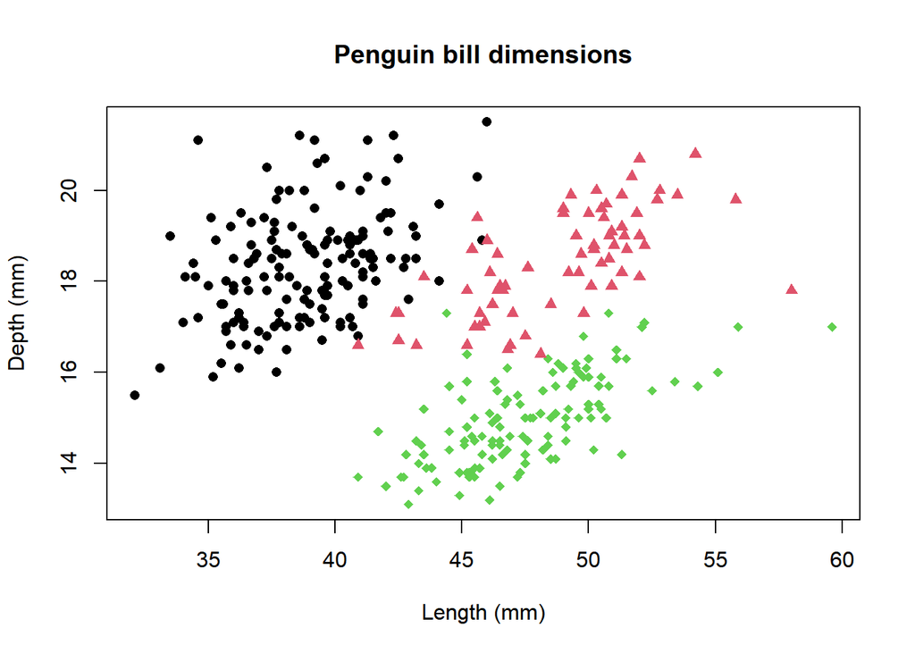

Figure 2: Penguin bill dimensions by species: Adelie (black circles), Chinstrap (red triangles) and Gentoo (green diamonds).

```r
plot(
  x = penguins$bill_length_mm,
  y = penguins$bill_depth_mm,
  main = "Penguin bill dimensions",
  xlab = "Length (mm)",
  ylab = "Depth (mm)",
  pch = 15 + as.numeric(penguins$species),
  col = penguins$species)
```

If we are plotting lines instead, we can also change the line width and type.

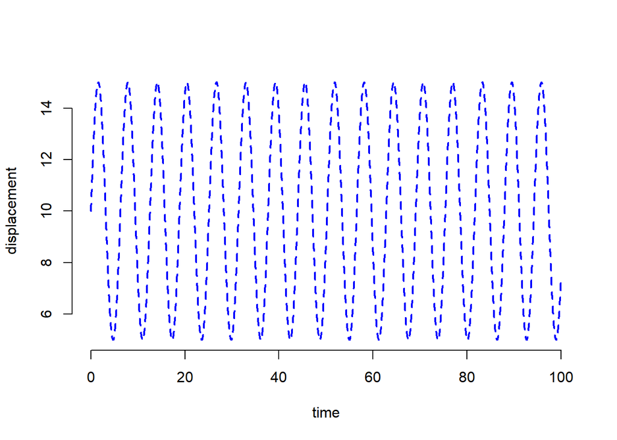

Figure 3: Displacement of an undamped simple harmonic oscillator.

```r
time <- seq(from = 0, to = 100, by = 0.01)
displacement <- 10 + 5 * sin(time)

plot(
  x = time,
  y = displacement,
  type = "l",
  bty = "n",
  col = "blue",
  lwd = 2, # line width
  lty = 2) # dashed line
```

## Layering your plots

We can overlay a line on our previous plot using `lines()`.

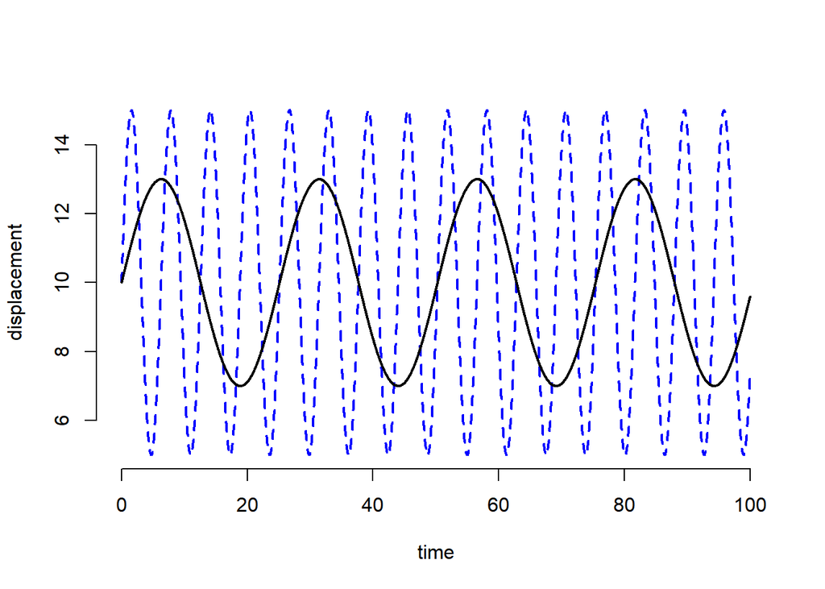

```r
plot(
  x = time,
  y = displacement,
  type = "l",
  bty = "n",
  col = "blue",
  lwd = 2, # line width
  lty = 2) # dashed line
spring_2 = 10 + 3 * sin(0.25 * time)
lines(x = time, y = spring_2, lwd = 2)
```

Similarly, we can add one or more points to the plot by using `points()`.

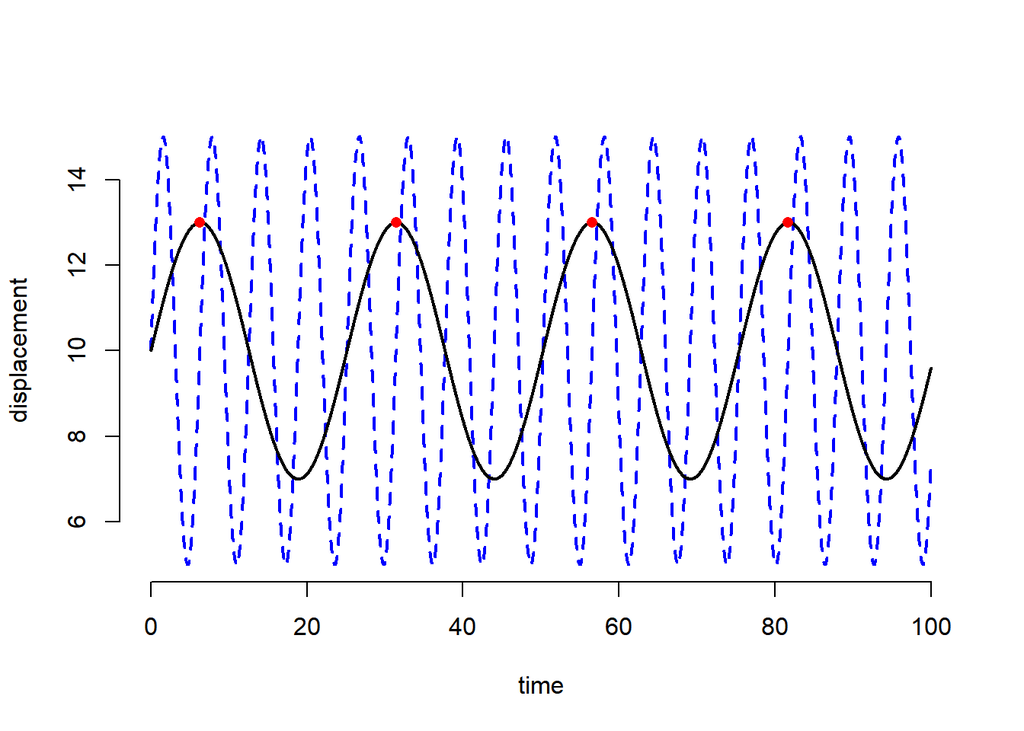

```r
plot(
  x = time,
  y = displacement,
  type = "l",
  bty = "n",
  col = "blue",
  lwd = 2,
  lty = 2)
lines(x = time, y = spring_2, lwd = 2)
points(x = c(2, 10, 18, 26) * pi, y = rep(13, 4), pch = 16, col = "red")
```

Finally, we might want to add a legend layer to our earlier scatterplot in Figure 2.

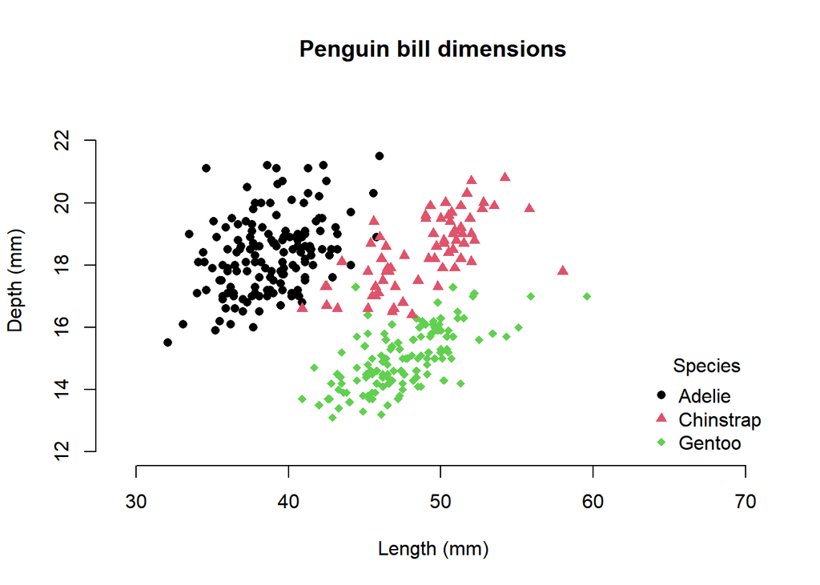

Penguin bill dimensions by species.

```r
plot(
  x = penguins$bill_length_mm,
  y = penguins$bill_depth_mm,
  col = penguins$species,
  pch = 15 + as.numeric(penguins$species),
  xlim = c(29,70), # extend plotting area to make room for legend
  ylim = c(12,23),
  main = "Penguin bill dimensions",
  xlab = "Length (mm)",
  ylab = "Depth (mm)",
  bty = "n")
legend(
  "bottomright",
  title = "Species",
  legend = c("Adelie", "Chinstrap", "Gentoo"),
  pch = 16:18,
  col = 1:3,
  bty = "n")
```

## Combining your plots

````markdown
```{r}
#| layout-ncol: 2
#| label: fig-example-plots
#| fig-cap: "Two example plots relating to the Gaussian distribution."
#| fig-subcap:
#|   - "Gaussian distribution"
#|   - "Gaussian QQ-plot"

x <- seq(from = -3, to = 3,by = 0.01)
density <- dnorm(x, mean = 0, sd = 1)

plot(
  x = x,
  y = density,
  bty = "n",
  cex.axis = 1.4,
  cex.lab = 1.4,
  type = "l",
  lwd = 2)

y <- rnorm(n = 100, mean = 3, sd = 2)
qqnorm(y, cex.axis = 1.4, cex.lab = 1.4, main = "")
```
````

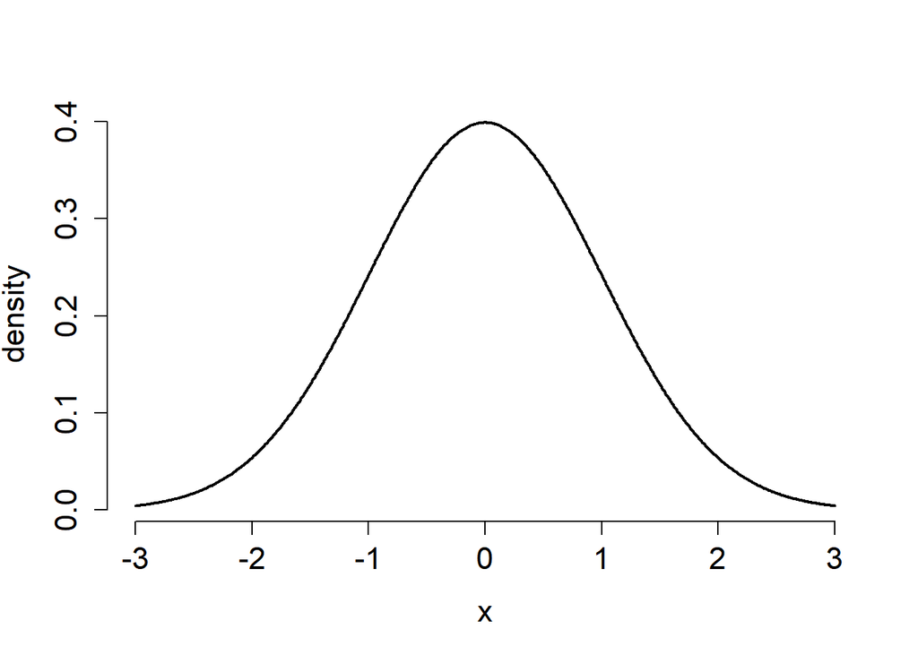

(a) Gaussian distribution

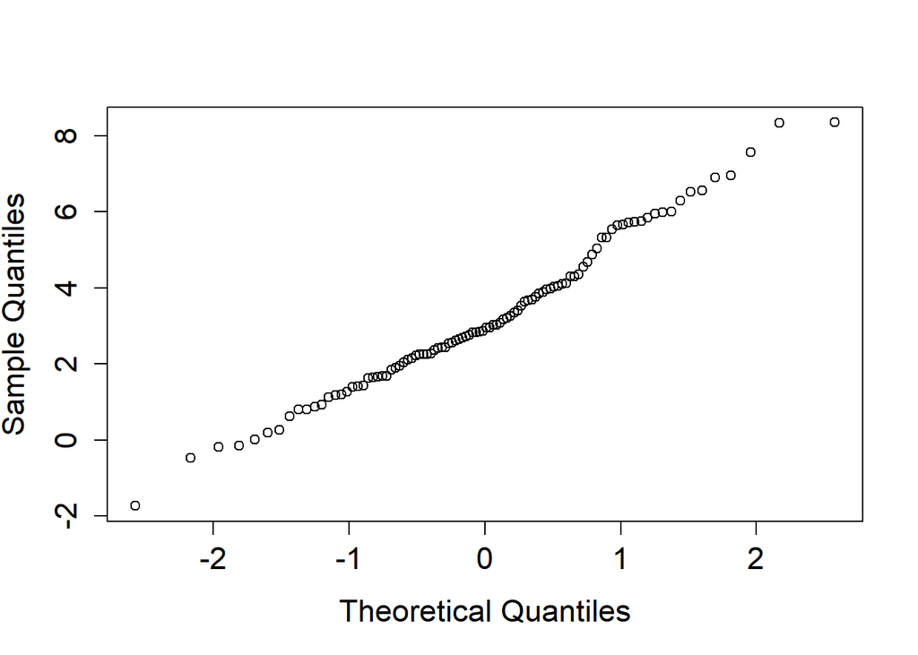

(b) Gaussian QQ-plot

Figure 4: Two example plots relating to the Gaussian distribution.

```r
x <- seq(from = -3, to = 3,by = 0.01)
density <- dnorm(x, mean = 0, sd = 1)

plot(
  x = x,
  y = density,
  bty = "n",
  cex.axis = 1.4,
  cex.lab = 1.4,
  type = "l",
  lwd = 2)

y <- rnorm(n = 100, mean = 3, sd = 2)
qqnorm(y, cex.axis = 1.4, cex.lab = 1.4, main = "")
```

Figure 4 shows how we can create multiple plots within a code block and then have these appear within the same figure as sub-figures. A probability density function is shown in Figure 4 (a), while a quantile-quantile plot is shown in Figure 4 (b).

## What goes where? Tiles, Captions and Descriptions

| Aspect | Plot Title | Figure Caption |
| --- | --- | --- |
| Location | Inside or above the plot | Outside the plot |
| Purpose | Quick context for the plot | Formal description with interpretive context |
| Referencing | Rarely referenced in the text | Commonly referenced (e.g., “see Figure 1”) |

Where a figure or table is mentioned in the main text you should explain *how* it supports any claims that you are making.

> BAD: Figure 2 demonstrates Simpson’s paradox.

> GOOD: Figure 2 shows that while there appears to be a positive association between bill length and depth *within* each species, this association disappears or perhaps reverses when considering all species together. This is an example of Simpson’s paradox [simpson1951contingency].

## Useful Resources

- Imperial Coursework Report Template
- [Quarto documentation](https://quarto.org/docs/guide/)
- [Make a reprex, please](https://youtu.be/G5Nm-GpmrLw?si=-GkQa9hK1yWiW37-)
- Telling Stories With Data
  - [3 - Reproducilbe workflows](https://tellingstorieswithdata.com/03-workflow.html)
- R style guides [Google](https://google.github.io/styleguide/Rguide.html), [Tidyverse](https://style.tidyverse.org/).
- Effective Data Science
  - [1 - Organising your work](https://eds-notes.zakvarty.com/101-workflows-organising-your-work)
  - [8 - Exploratory data analysis](https://eds-notes.zakvarty.com/302-edav-analysis)
  - [9 - Data visualisation](https://eds-notes.zakvarty.com/303-edav-visualisation)
- [The TidyTuesday Cookbook](https://nrennie.rbind.io/art-of-viz/)

# Review

1. use R code within Quarto for single-document literate programming tasks
2. critique and refine default R outputs (such as plots and tables) for reports
3. understand how and when to show code within reports
4. use style guides and directory templates to provide a consistent structure across projects

### References

Box, George EP, and David R Cox. 1964. “An Analysis of Transformations.” *Journal of the Royal Statistical Society Series B: Statistical Methodology* 26 (2): 211–43.

Casella, George, and Roger Berger. 2024. *Statistical Inference*. Chapman; Hall/CRC.